Tài liệu này mang giấy phép Creative Commons Attribution (CC BY). (c) Nguyễn Ngọc Sáng, Zhukovsky 12/2018.

[@SangVn](https://github.com/SangVn) [@VnCFD](https://vncfdgroup.wordpress.com/)

*Thực hành CFD với Python!*

# Bài 17. Euler 1D solver: Godunov, MUSCL, WENO5, Runge-Kutta 3

Giống như bài 13, 14 ta sẽ thêm vào chương trình các sơ đồ MUSCL, WENO5. Điểm khác biệt giữa sơ đồ Godunov, MUSCL, WENO5 mà ta sử dụng nằm ở hàm tái cấu trúc nghiệm, còn các phần khác đều giống nhau và đã được lưu trong module euler_solver từ bài 16.

Đối với sơ đồ MUSCL ta chỉ xét giới hạn độ dốc `minmod`, đối với WENO5 ta xét trường hợp WENO5-Reconstruction. Các trường hợp còn lại các bạn tự nghiên cứu.

**Code** Phần code module euler_solver có chút thay đổi so với bài 16: thêm vào sơ đồ phương pháp `Runge-Kutta` bậc 1, bậc 3 như ta đã làm ở bài 14. Các bạn xem trong file euler_solver.py.

```python
import numpy as np
import matplotlib.pyplot as plt
from lib.euler_solver import*
from lib.burgers_solver import*

#sơ đồ MUSCL
def muscl_reconstr(Ps):
    P_left = Ps[:-1].copy()
    P_right = Ps[1:].copy()
    rs = (Ps[1:-1] - Ps[:-2])/(Ps[2:] - Ps[1:-1] + 1e-10)

    P_left[1:] = Ps[1:-1] + 0.5*minmod(rs[:])*(Ps[2:] - Ps[1:-1])
    P_left[0] = Ps[0] #điều kiện biên

    P_right[:-1] = Ps[1:-1] - 0.5*minmod(rs[:])*(Ps[2:] - Ps[1:-1])
    P_right[-1] = Ps[-1] #điều kiện biên
    return P_left, P_right

#P=(r, u, p): amax(a, P) = (max(a, r), max(a, u), max(a, p))
def amax(a, P):
    return np.array([max(a, pi) for pi in P])

def amin(a, P):
    return np.array([min(a, pi) for pi in P])

def minmod(rs):
    phi = np.array([amax(0, amin(1, r)) for r in rs])
    return phi
```

```python
#sơ đồ WENO5
def psum(a, P3):
    return a[0]*P3[0] + a[1]*P3[1] + a[2]*P3[2]

#Hàm tái cấu trúc nghiệm
def reconstr(Ps, beta, a_b, gamma, a_P, Ps_05):
    for i in range(2, len(Ps)-2): #for each cell in cells
        #bước 1. tính chỉ thị độ trơn trong từng khuôn S_j
        b0 = beta(a_b[0], Ps[i-2:i+1])
        b1 = beta(a_b[1], Ps[i-1:i+2])
        b2 = beta(a_b[2], Ps[i  :i+3])

        #bước 2. tìm trọng lượng phi tuyến từng khuôn
        omg_r = omega(gamma, np.array([b0[0], b1[0], b2[0]]))
        omg_u = omega(gamma, np.array([b0[1], b1[1], b2[1]]))
        omg_p = omega(gamma, np.array([b0[2], b1[2], b2[2]]))

        #bước 3. tìm xấp xỉ bậc 3
        P0 = psum(a_P[0], Ps[i-2:i+1])
        P1 = psum(a_P[1], Ps[i-1:i+2])
        P2 = psum(a_P[2], Ps[i  :i+3])

        #bước 4. tìm xấp xỉ bậc 5
        Ps_05[i, 0] = sum(omg_r*[P0[0], P1[0], P2[0]])
        Ps_05[i, 1] = sum(omg_u*[P0[1], P1[1], P2[1]])
        Ps_05[i, 2] = sum(omg_p*[P0[2], P1[2], P2[2]])

        #Điều kiện biên: u_05[0], u_05[1], u_05[-2], u_05[-1]
    return

def weno5_reconstr(Ps):
    P_left = Ps.copy()
    P_right = Ps.copy()
    reconstr(Ps, beta_Rct, a_bRct, gamma_Rct_p05, a_uRct_p05, P_left)
    reconstr(Ps, beta_Rct, a_bRct, gamma_Rct_m05, a_uRct_m05, P_right)

    return P_left[:-1], P_right[1:]
```

```python
def plot(Ps1, Ps2, Ps3, Ps4):
    e1 = Ps1[2]/(gm1*Ps1[0])
    e2 = Ps2[2]/(gm1*Ps2[0])
    e3 = Ps3[2]/(gm1*Ps3[0])
    e4 = Ps4[2]/(gm1*Ps4[0])

    f, axarr = plt.subplots(2, 2, figsize=(18,12))
    axarr[0, 0].plot(x, Ps1[0], x, Ps2[0], x, Ps3[0], x, Ps4[0])
    axarr[0, 0].set_title('density')
    axarr[0, 1].plot(x, Ps1[1], x, Ps2[1], x, Ps3[1], x, Ps4[1])
    axarr[0, 1].set_title('velocity')
    axarr[1, 0].plot(x, Ps1[2], x, Ps2[2], x, Ps3[2], x, Ps4[2])
    axarr[1, 0].set_title('pressure')
    axarr[1, 1].plot(x, e1, x, e2, x, e3, x, e4)
    axarr[1, 1].set_title('energy')
    f.subplots_adjust(hspace=0.2)
    plt.legend(['exact solution', 'godunov reconstr', 'muscl reconstr', 'weno5 reconstr'])
    plt.show()

def solver():
    Ps = np.zeros((nx, 3))
    Ps[:int(xstar/dx)] = Pl
    Ps[int(xstar/dx):] = Pr

    P_exact = riemann_exact_solution(Pl, Pr, pressure_solver, x, xstar, t_max)
    #runge-kutta 1 = euler
    P_godunov = euler_solver(Ps.copy(), pressure_solver, godunov_reconstr, 1, x, t_max, CFL=0.45)
    P_muscl = euler_solver(Ps.copy(), pressure_solver, muscl_reconstr, 1, x, t_max, CFL=0.45)
    #runge-kutta 3
    P_weno5 = euler_solver(Ps.copy(), pressure_solver, weno5_reconstr, 3, x, t_max, CFL=0.45)
    plot(P_exact, P_godunov.T, P_muscl.T, P_weno5.T)
```

Kiểm tra kết quả:

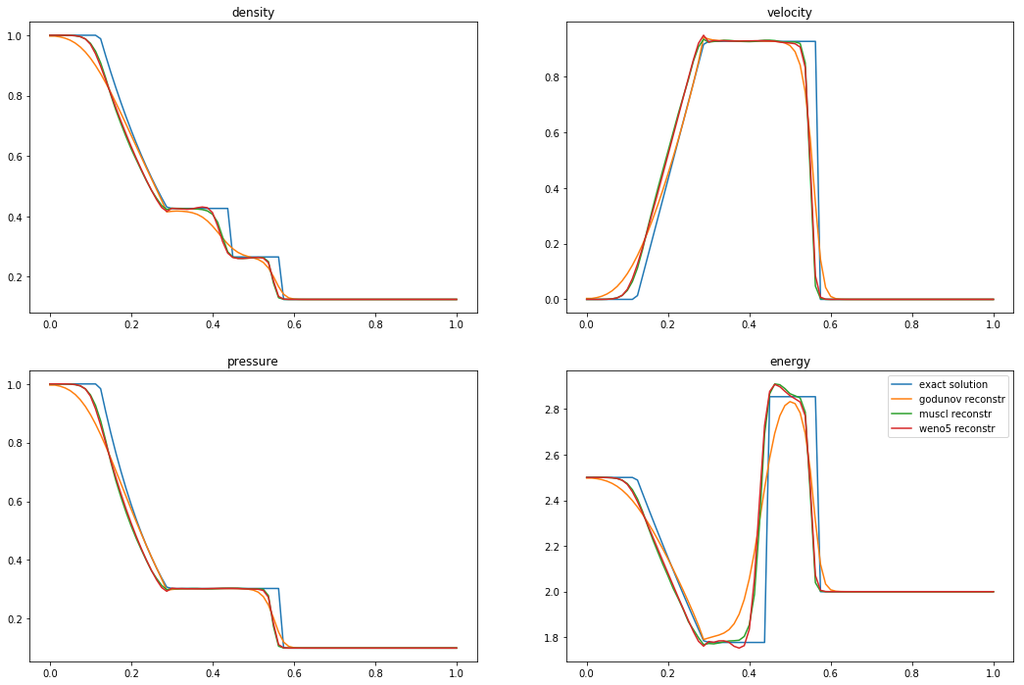

```
CPU times: user 2.61 s, sys: 9.98 ms, total: 2.62 s
Wall time: 2.62 s
```

```python
#chia lưới
nx = 81
x, dx = np.linspace(0, 1, nx, retstep=True)
pressure_solver = pressure_classic_godunov
# pressure_solver = pressure_root_finding

#test 1
Pl = [1.0, 0.0, 1.0]
Pr = [0.125, 0.0, 0.1]
xstar = 0.3
t_max = 0.15

%time solver()
```

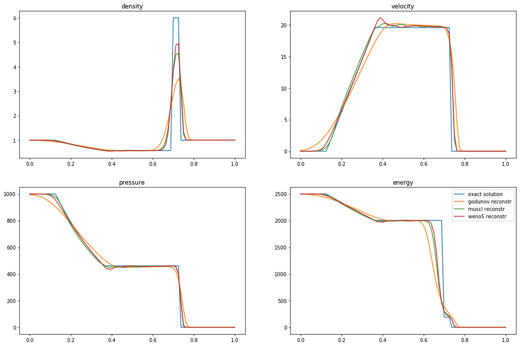

```
CPU times: user 4.38 s, sys: 31.6 ms, total: 4.42 s
Wall time: 4.41 s
```

```python
#test 2
Pl = [1.0, 0.0, 1000.0]
Pr = [1.0, 0.0, 0.01]
xstar = 0.5
t_max = 0.01

%time solver()
```

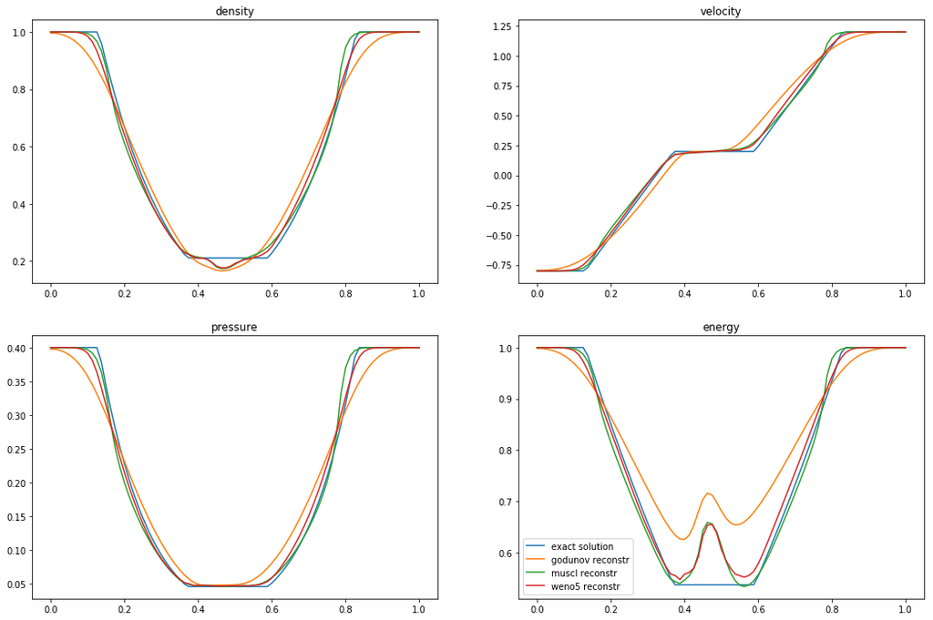

```
CPU times: user 3.21 s, sys: 3.99 ms, total: 3.22 s
Wall time: 3.21 s
```

```python
#test 3
Pl = [1.0, -0.8, 0.4]
Pr = [1.0, 1.2, 0.4]
xstar = 0.44
t_max = 0.2

%time solver()
```

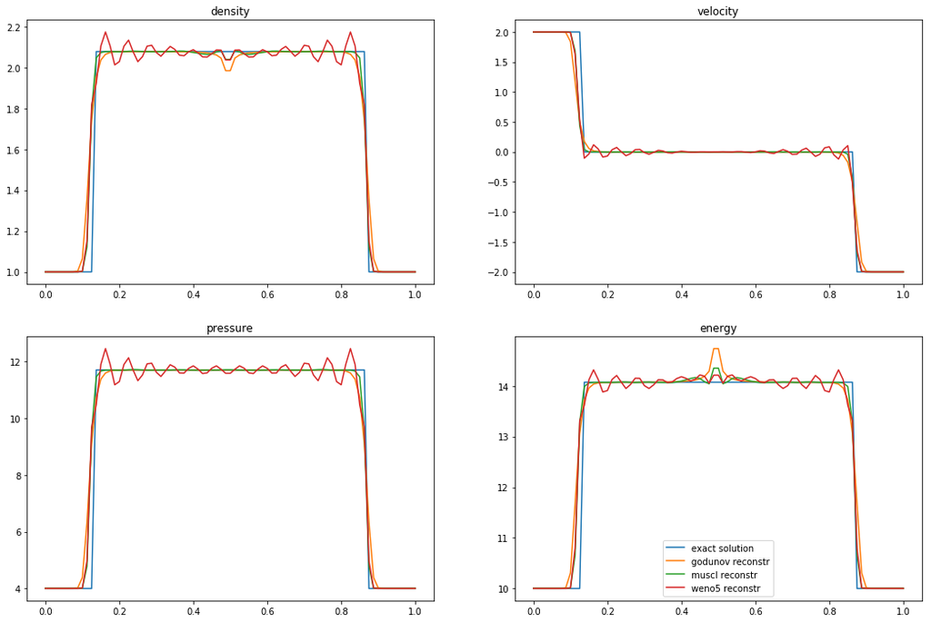

```
CPU times: user 6.81 s, sys: 7.91 ms, total: 6.82 s
Wall time: 6.81 s
```

```python
#test 4
Pl = [1.0, 2.0, 4.0]
Pr = [1.0, -2.0, 4.0]
xstar = 0.5
t_max = 0.2

%time solver()
```

# Đánh giá kết quả

Những bài toán mà chúng ta dùng để so sánh đều có đặc trưng chung đó là có nhiều gián đoạn, đứt gãy. Kết quả cho ta thấy phương pháp `tái cấu trúc hằng số từng mảnh` Godunov cho kết quả kém chính nhất. Tái cấu trúc MUSCL và WENO5 cho kết quả khá tương đồng, tuy nhiên WENO5 làm xuất hiện nhiều dao động. Đối với các dạng bài toán có tính chất như trên ta nên sử dụng tái cấu trúc MUSCL.

Như ở bài 15 đã đánh giá, WENO5 chiếm ưu thế so với MUSCL khi trong bài toán có nhiều điểm cực trị. Ta sẽ kiểm chứng bằng bài toán [**Shu-Osher** -(tham khảo)](http://www.ttctech.com/Samples/shockwave/shockwave.htm).

### Điều kiện ban đầu

$$(\rho, u, p)_l = (3.857143, 2.629369, 10.3333)\\ (\rho, u, p)_r = (1+0.2sin(5x-25), 0.0, 1.0)\\ x_{star} = 1.0 $$

```python
#shu-osher problem
Pl = [3.857143, 2.629369, 10.3333]
Pr = [1.2, 0.0, 1.0]
xstar = 1
t_max = 1.8

#sử dụng các lưới khác nhau:
#lưới mịn
nx_f = 1001
x_fine, dx_f = np.linspace(0, 10, nx_f, retstep=True)

#điều kiện ban đầu
Ps_fine = np.zeros((nx_f, 3))
istar = int(xstar/dx_f)
Ps_fine[:istar] = Pl
Ps_fine[istar:] = Pr

for i in range(istar, nx_f): Ps_fine[i][0] = 1 + 0.2*np.sin(5*x_fine[i] - 25)

#lưới thô
nx_c = 401
x_coarse, dx_c = np.linspace(0, 10, nx_c, retstep=True)

#điều kiện ban đầu
Ps_coarse = np.zeros((nx_c, 3))
istar = int(xstar/dx_c)
Ps_coarse[:istar] = Pl
Ps_coarse[istar:] = Pr

for i in range(istar, nx_c): Ps_coarse[i][0] = 1 + 0.2*np.sin(5*x_coarse[i] - 25)
```

```python
%time P_muscl = euler_solver(Ps_coarse.copy(), pressure_solver, muscl_reconstr, 3, x_coarse, t_max, CFL=0.45)
```

```
CPU times: user 25.6 s, sys: 19.9 ms, total: 25.6 s
Wall time: 25.6 s
```

```python
%time P_weno5 = euler_solver(Ps_coarse.copy(), pressure_solver, weno5_reconstr, 3, x_coarse, t_max, CFL=0.45)
```

```
CPU times: user 2min 17s, sys: 310 ms, total: 2min 17s
Wall time: 2min 17s
```

```python
%time P_exact = euler_solver(Ps_fine.copy(), pressure_solver, muscl_reconstr, 3, x_fine, t_max, CFL=0.45)
```

```
CPU times: user 2min 32s, sys: 196 ms, total: 2min 32s
Wall time: 2min 32s
```

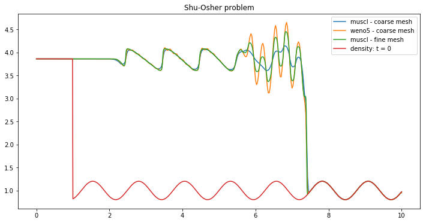

```python
fig = plt.figure(figsize=(12, 6))
plt.plot(x_coarse, P_muscl.T[0], x_coarse, P_weno5.T[0], x_fine, P_exact.T[0], x_fine, Ps_fine.T[0])
plt.legend(['muscl - coarse mesh', 'weno5 - coarse mesh', 'muscl - fine mesh', 'density: t = 0'])
plt.title('Shu-Osher problem')
plt.savefig('Shu-Osher_problem.png')
plt.show()
```

Kết quả cho thấy, sơ đồ WENO5 cho kết quả tốt hơn ở vùng phía sau giáp với mặt sóng xung kích. Ở vùng bắt đầu nhiễu động, để ý kĩ các bạn sẽ thấy sơ đồ WENO5 làm xuất hiện các dao động nhỏ cục bộ. Tích phân thời gian bằng phương pháp Runge-Kutta bậc 3 là chưa đủ. Các bạn hãy thử với Runge-Kutta bậc 4. Nếu sử dụng Runge-Kutta bậc 1 cho sơ đồ MUSCL sẽ thu được tình trạng tương tự, hãy kiểm tra với Runge-Kutta bậc 2.

Về mặt thời gian tính toán, sơ đồ WENO5 chạy chậm hơn. Ta cũng thấy rằng, chỉ một bài toán nhỏ như vậy, lưới 1001 điểm, sơ đồ MUSCL chạy mất 2'32". Chúng ta bắt đầu `thấm thía sự chờ đợi`. Cũng chính vì vậy nên cần thiết phải nghiên cứu `sơ đồ ẩn` và `tính toán song song`. Ngoài ra hãy nghiên cứu thêm phương pháp tìm áp suất P xấp xỉ ví dụ như phương pháp xấp xỉ Roe.

Tổng hợp code và tối ưu các bạn đã có trong tay thư viện hỗ trợ tính toán hệ phương trình Euler 1D. Tham khảo thư viện [**vncfd_1D**](https://github.com/SangVn/vncfd_1D).

*Chúc các bạn sức khỏe và hẹn gặp lại ở các phần sau!*